# Comparison Between Experiments

In 20_03_03_comparisons.html we tried performing enrichment analysis on the different groups of DE genes depending on the brain region they were found to be significant in, but it didn’t give very good results, probably because there are probably many different signals combined in each of these groups (for example, the under and overexpressed genes probably belong to different pathways).

To study this, we already have the WGCNA modules created using the data from all the brain regions, so we just need to perform an enrichment analysis using each of these groups of DE genes as collections, find the modules which are “enriched” in any of these groups and perform a functional enrichment analysis on these modules.

```r
###################################################################################################
# Gene Expression data

# All Regions
load('./../../AllRegions/Data/preprocessed_data.RData')
datExpr_all = datExpr %>% data.frame
DE_info_all = DE_info %>% data.frame %>% mutate(ID = rownames(.))
datMeta_full = datMeta %>% dplyr::select(-matches('SV|Picard'))

# Frontal
load('./../../Frontal/Data/preprocessed_data.RData')
datExpr_frontal = datExpr %>% data.frame
DE_info_frontal = DE_info %>% data.frame %>% mutate(ID = rownames(.))
datMeta = datMeta %>% dplyr::select(-matches('SV|Picard'))
datMeta_full = rbind(datMeta_full, datMeta) %>% distinct(Sample_ID, .keep_all = TRUE)

# Occipital
load('./../../Occipital/Data/preprocessed_data.RData')
datExpr_occipital = datExpr %>% data.frame
DE_info_occipital = DE_info %>% data.frame %>% mutate(ID = rownames(.))
datMeta = datMeta %>% dplyr::select(-matches('SV|Picard'))
datMeta_full = rbind(datMeta_full, datMeta) %>% distinct(Sample_ID, .keep_all = TRUE)

# Without Occipital
load('./../../NoOccipital/Data/preprocessed_data.RData')
datExpr_no_occipital = datExpr %>% data.frame
DE_info_no_occipital = DE_info %>% data.frame %>% mutate(ID = rownames(.))
datMeta = datMeta %>% dplyr::select(-matches('SV|Picard'))
datMeta_full = rbind(datMeta_full, datMeta) %>% distinct(Sample_ID, .keep_all = TRUE)

# Get Entrez Gene ID for all genes
all_genes = unique(c(DE_info_all$ID, DE_info_frontal$ID,
                     DE_info_occipital$ID, DE_info_no_occipital$ID))
getinfo = c('ensembl_gene_id','entrezgene')
mart = useMart(biomart='ENSEMBL_MART_ENSEMBL', dataset='hsapiens_gene_ensembl', host='feb2014.archive.ensembl.org')
genes_EntrezGeneID = getBM(attributes=getinfo, filters=c('ensembl_gene_id'), values=all_genes, mart=mart)
colnames(genes_EntrezGeneID)[1] = 'ID'

###################################################################################################

# SFARI Genes
SFARI_genes = read_csv('./../../../SFARI/Data/SFARI_genes_08-29-2019_w_ensembl_IDs.csv')
SFARI_genes = SFARI_genes[!duplicated(SFARI_genes$ID) & !is.na(SFARI_genes$ID),]

###################################################################################################

# GO Neuronal annotations: regex 'neuron' in GO functional annotations and label the genes that make a match as neuronal
GO_annotations = read.csv('./../../AllRegions/Data/genes_GO_annotations.csv')
GO_neuronal = GO_annotations %>% filter(grepl('neuron', go_term)) %>%
              mutate('ID'=as.character(ensembl_gene_id)) %>%
              dplyr::select(-ensembl_gene_id) %>% distinct(ID) %>%
              mutate('Neuronal'=1)

###################################################################################################

# Prepare datasets for enrichment analysis
GO_col = buildGOcollection(organism = 'human', verbose = 0)
internal_col = internalCollection(organism = 'human')
MillerAIBS_col = MillerAIBSCollection(organism = 'human')
BrainDisease_col = BrainDiseaseCollection(organism = 'human')
combined_col = mergeCollections(GO_col, internal_col, MillerAIBS_col, BrainDisease_col)



rm(GO_annotations, datMeta, datExpr, datGenes, dds, DE_info, GO_col, internal_col, MillerAIBS_col,
   BrainDisease_col, getinfo, mart)
```

## DE Genes

```r
genes_df = data.frame('All' = all_genes %in% DE_info_all$ID[DE_info_all$padj<0.05],
                      'Fro' = all_genes %in% DE_info_frontal$ID[DE_info_frontal$padj<0.05],
                      'Occ' = all_genes %in% DE_info_occipital$ID[DE_info_occipital$padj<0.05],
                      'NoO' = all_genes %in% DE_info_no_occipital$ID[DE_info_no_occipital$padj<0.05],
                      'ID' = all_genes)
rownames(genes_df) = all_genes
genes_df = genes_df[genes_df$All+genes_df$Fro+genes_df$Occ+genes_df$NoO>0,]

cat(paste0('Total number of DE genes: ', nrow(genes_df)))
```

```
## Total number of DE genes: 7114
```

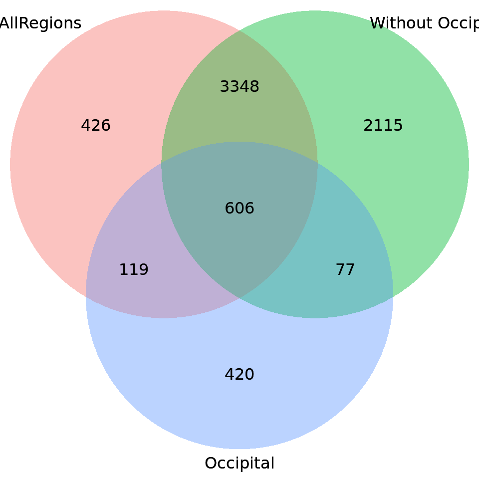

```r
grid.newpage()
grid.draw(draw.triple.venn(sum(genes_df$All), sum(genes_df$NoO), sum(genes_df$Occ),
                           sum(genes_df$All*genes_df$NoO), sum(genes_df$Occ*genes_df$NoO), sum(genes_df$All*genes_df$Occ),
                           sum(genes_df$All*genes_df$NoO*genes_df$Occ),
          category = c('AllRegions', 'Without Occipital', 'Occipital'),
          fill = hcl(h=seq(15, 375, length=4), l=65, c=100)[-4], fontfamily = rep('sans-serif',7),
          alpha = rep(0.25,3), lty = rep('blank', 3), cat.fontfamily = rep('sans-serif',3)))
```

```r
rm(datExpr_all, datExpr_frontal, datExpr_no_occipital, datExpr_occipital, DE_info_all,
   DE_info_frontal, DE_info_no_occipital, DE_info_occipital)
```

### Enrichment analysis of DE genes in WGCNA modules

Load WGCNA modules

```r
clustering = read_csv('./../../AllRegions/Data/clusters.csv') %>% dplyr::select(ID, DynamicHybrid)
```

#### Define DE gene groups as anRichment gene sets

```r
### CREATE GENE SETS
create_GeneSet = function(entrez, ID, name){

  GeneSet = newGeneSet(geneEntrez = entrez, ID = ID, name = name, shortName = name,
                       internalClassification = name, description = '', geneEvidence = 'IEP',
                       geneSource = 'DE Genes in Gandal\'s dataset',
                       source = 'DEA from Gandal\'s dataset filtering by different brain regions',
                       organism = 'human', groups = 'DE_by_region', lastModified = '2020-03-09')

  return(GeneSet)
}

# DE in a single dataset
entrez = unique(genes_EntrezGeneID$entrezgene[genes_EntrezGeneID$ID %in% genes_df$ID[genes_df$All & !genes_df$Occ & !genes_df$NoO]])
AllRegions_only_GeneSet = create_GeneSet(entrez, 'DE_AllRegions_only', 'DE Genes in AllRegions dataset only')

entrez = unique(genes_EntrezGeneID$entrezgene[genes_EntrezGeneID$ID %in% genes_df$ID[!genes_df$All & genes_df$Occ & !genes_df$NoO]])
Occipital_only_GeneSet = create_GeneSet(entrez, 'DE_Occipital_only', 'DE Genes in Occipital dataset only')

entrez = unique(genes_EntrezGeneID$entrezgene[genes_EntrezGeneID$ID %in% genes_df$ID[!genes_df$All & !genes_df$Occ & genes_df$NoO]])
NoOccipital_only_GeneSet = create_GeneSet(entrez, 'DE_Without_Occipital_only', 'DE Genes in dataset without Occipital lobe only')

# DE in two datasets
entrez = unique(genes_EntrezGeneID$entrezgene[genes_EntrezGeneID$ID %in% genes_df$ID[genes_df$All & genes_df$Occ & !genes_df$NoO]])
AllRegions_Occipital_GeneSet = create_GeneSet(entrez, 'DE_AllRegions_Occipital', 'DE Genes in AllRegions and Occipital datasets')

entrez = unique(genes_EntrezGeneID$entrezgene[genes_EntrezGeneID$ID %in% genes_df$ID[genes_df$All & !genes_df$Occ & genes_df$NoO]])
AllRegions_NoOccipital_GeneSet = create_GeneSet(entrez, 'DE_AllRegions_Wo_Occipital', 'DE Genes in All Regions and without Occipital datasets')

entrez = unique(genes_EntrezGeneID$entrezgene[genes_EntrezGeneID$ID %in% genes_df$ID[!genes_df$All & genes_df$Occ & genes_df$NoO]])
Occipital_NoOccipital_GeneSet = create_GeneSet(entrez, 'DE_Occipital_Without_Occipital', 'DE Genes in Occipital and without Occipital datasets')

# DE in two datasets
entrez = unique(genes_EntrezGeneID$entrezgene[genes_EntrezGeneID$ID %in% genes_df$ID[genes_df$All & genes_df$Occ & genes_df$NoO]])
All_GeneSet = create_GeneSet(entrez, 'DE_all_datasets', 'DE Genes in all three datasets')



### CREATE GROUP
DEgroup =  newGroup(name = 'DE_by_region', description = 'Genes found to be DE for different regions of the brain',
                    source = 'DEA from Gandal\'s dataset filtering by different brain regions')



### CREATE COLLECTION
dataSets_list = list(AllRegions_only_GeneSet, Occipital_only_GeneSet, NoOccipital_only_GeneSet,
                     AllRegions_Occipital_GeneSet, AllRegions_NoOccipital_GeneSet, Occipital_NoOccipital_GeneSet,
                     All_GeneSet)

DEcollection = newCollection(dataSets = dataSets_list, groups = list(DEgroup))


rm(AllRegions_only_GeneSet, Occipital_only_GeneSet, NoOccipital_only_GeneSet, AllRegions_Occipital_GeneSet,
   AllRegions_NoOccipital_GeneSet, Occipital_NoOccipital_GeneSet, All_GeneSet, create_GeneSet,
   dataSets_list, DEgroup, entrez)
```

#### Perform enrichment analysis

- Using as the pool of genes only the ones assigned to a module in WGCNA and with an entrezID assigned to them

```r
EA_dataset = genes_EntrezGeneID %>% left_join(clustering, by='ID') %>% filter(!is.na(DynamicHybrid) & DynamicHybrid!='gray') %>%
             left_join(genes_df, by='ID') %>% dplyr::select(-c(All, Occ, NoO, Fro)) %>% filter(!is.na(entrezgene))

# Using useBackground = 'given' because it is recommended when the collection is not that big (<10K genes)
enrichment = enrichmentAnalysis(classLabels = EA_dataset$DynamicHybrid, identifiers = EA_dataset$entrezgene,
                                refCollection = DEcollection, threshold = 1e-4, thresholdType = 'Bonferroni',
                                getOverlapEntrez = FALSE, getOverlapSymbols = TRUE, useBackground = 'given')
```

```
##  enrichmentAnalysis: preparing data..
##   ..working on label set 1 ..
```

```r
enrichment_DE = enrichment$enrichmentTable %>%
                dplyr::select(class, dataSetID, shortDataSetName, Bonferroni, FDR, enrichmentRatio,
                              effectiveClassSize, effectiveSetSize, nCommonGenes) %>%
                filter(Bonferroni<0.05) %>% arrange(Bonferroni, desc(enrichmentRatio))

kable(enrichment_DE, caption='Enrichment of DE genes in WGCNA modules')
```

Enrichment of DE genes in WGCNA modules

| class | dataSetID | shortDataSetName | Bonferroni | FDR | enrichmentRatio | effectiveClassSize | effectiveSetSize | nCommonGenes |
| --- | --- | --- | --- | --- | --- | --- | --- | --- |
| #00B9E3 | DE_all_datasets | DE Genes in all three datasets | 0.0000000 | 0.0000000 | 3.206573 | 1738 | 611 | 211 |
| #00C19F | DE_AllRegions_Wo_Occipital | DE Genes in All Regions and without Occipital datasets | 0.0000000 | 0.0000000 | 2.371741 | 433 | 3410 | 217 |
| #DB72FB | DE_AllRegions_Wo_Occipital | DE Genes in All Regions and without Occipital datasets | 0.0000000 | 0.0000000 | 1.981286 | 504 | 3410 | 211 |
| #00B9E3 | DE_AllRegions_Wo_Occipital | DE Genes in All Regions and without Occipital datasets | 0.0000000 | 0.0000000 | 1.440460 | 1738 | 3410 | 529 |
| #00C1AC | DE_AllRegions_Wo_Occipital | DE Genes in All Regions and without Occipital datasets | 0.0000000 | 0.0000000 | 1.858780 | 387 | 3410 | 152 |
| #DB72FB | DE_AllRegions_only | DE Genes in AllRegions dataset only | 0.0000001 | 0.0000000 | 3.096258 | 504 | 424 | 41 |
| #00BD63 | DE_Without_Occipital_only | DE Genes in dataset without Occipital lobe only | 0.0000003 | 0.0000000 | 2.270488 | 193 | 2136 | 58 |
| #FE61CF | DE_AllRegions_Wo_Occipital | DE Genes in All Regions and without Occipital datasets | 0.0000030 | 0.0000004 | 1.646105 | 322 | 3410 | 112 |
| #619CFF | DE_Without_Occipital_only | DE Genes in dataset without Occipital lobe only | 0.0000051 | 0.0000006 | 1.709699 | 464 | 2136 | 105 |
| #998EFF | DE_AllRegions_Wo_Occipital | DE Genes in All Regions and without Occipital datasets | 0.0000234 | 0.0000023 | 1.682274 | 256 | 3410 | 91 |
| #FF66AA | DE_AllRegions_Wo_Occipital | DE Genes in All Regions and without Occipital datasets | 0.0000256 | 0.0000023 | 1.323231 | 1005 | 3410 | 281 |
| #5EB300 | DE_AllRegions_Wo_Occipital | DE Genes in All Regions and without Occipital datasets | 0.0000937 | 0.0000078 | 2.114544 | 94 | 3410 | 42 |
| #93AA00 | DE_all_datasets | DE Genes in all three datasets | 0.0003534 | 0.0000272 | 3.402830 | 163 | 611 | 21 |
| #00C1AC | DE_AllRegions_only | DE Genes in AllRegions dataset only | 0.0005180 | 0.0000370 | 2.753791 | 387 | 424 | 28 |
| #00B6EC | DE_AllRegions_Wo_Occipital | DE Genes in All Regions and without Occipital datasets | 0.0005746 | 0.0000383 | 2.669644 | 39 | 3410 | 22 |
| #73B000 | DE_AllRegions_only | DE Genes in AllRegions dataset only | 0.0007813 | 0.0000488 | 1.775151 | 1458 | 424 | 68 |
| #84AD00 | DE_AllRegions_Wo_Occipital | DE Genes in All Regions and without Occipital datasets | 0.0015169 | 0.0000892 | 1.293135 | 882 | 3410 | 241 |
| #FF699C | DE_all_datasets | DE Genes in all three datasets | 0.0018893 | 0.0001050 | 2.282556 | 405 | 611 | 35 |
| #00ADFA | DE_Without_Occipital_only | DE Genes in dataset without Occipital lobe only | 0.0020530 | 0.0001081 | 1.908693 | 190 | 2136 | 48 |
| #84AD00 | DE_all_datasets | DE Genes in all three datasets | 0.0027885 | 0.0001394 | 1.796765 | 882 | 611 | 60 |
| #AE87FF | DE_AllRegions_Wo_Occipital | DE Genes in All Regions and without Occipital datasets | 0.0029882 | 0.0001423 | 2.747933 | 31 | 3410 | 18 |
| #FA62DA | DE_AllRegions_only | DE Genes in AllRegions dataset only | 0.0243889 | 0.0011086 | 3.415760 | 156 | 424 | 14 |
| #FC727E | DE_Without_Occipital_only | DE Genes in dataset without Occipital lobe only | 0.0278521 | 0.0012110 | 1.876466 | 153 | 2136 | 38 |

```r
rm(enrichment)
```

Enriched modules were four for only four of the seven groups of DE genes

- The Occipital DE dataset seems to be missing almost completely (only present in the intersection of all three datasets), perhaps the network constructed with only that brain lobe is too different to the one considering all of the brain regions? Also, it was the one with the least amount of DE genes, which could also be a factor

```r
cat(paste0('Found ', length(unique(enrichment_DE$class)), ' enriched modules'))
```

```
## Found 19 enriched modules
```

```r
sort(table(enrichment_DE$dataSetID), decreasing = TRUE)
```

```
##
## DE_AllRegions_Wo_Occipital            DE_all_datasets
##                         11                          4
##         DE_AllRegions_only  DE_Without_Occipital_only
##                          4                          4
```

```r
enriched_modules = table(enrichment_DE$class, enrichment_DE$dataSetID) %>% data.frame %>% dcast(Var1 ~ Var2) %>%
                   mutate('Total' = DE_all_datasets+DE_AllRegions_only+DE_AllRegions_Wo_Occipital+DE_Without_Occipital_only) %>%
                   arrange(desc(Total))

colnames(enriched_modules) = c('Module', 'All', 'AllRegions Only', 'AllRegions and w/o Occipital', 'W/o Occipital Only', 'Total')

kable(enriched_modules, caption='Modules enriched in a least one of the DE groups of genes')
```

Modules enriched in a least one of the DE groups of genes

| Module | All | AllRegions Only | AllRegions and w/o Occipital | W/o Occipital Only | Total |
| --- | --- | --- | --- | --- | --- |
| #00B9E3 | 1 | 0 | 1 | 0 | 2 |
| #00C1AC | 0 | 1 | 1 | 0 | 2 |
| #84AD00 | 1 | 0 | 1 | 0 | 2 |
| #DB72FB | 0 | 1 | 1 | 0 | 2 |
| #00ADFA | 0 | 0 | 0 | 1 | 1 |
| #00B6EC | 0 | 0 | 1 | 0 | 1 |
| #00BD63 | 0 | 0 | 0 | 1 | 1 |
| #00C19F | 0 | 0 | 1 | 0 | 1 |
| #5EB300 | 0 | 0 | 1 | 0 | 1 |
| #619CFF | 0 | 0 | 0 | 1 | 1 |
| #73B000 | 0 | 1 | 0 | 0 | 1 |
| #93AA00 | 1 | 0 | 0 | 0 | 1 |
| #998EFF | 0 | 0 | 1 | 0 | 1 |
| #AE87FF | 0 | 0 | 1 | 0 | 1 |
| #FA62DA | 0 | 1 | 0 | 0 | 1 |
| #FC727E | 0 | 0 | 0 | 1 | 1 |
| #FE61CF | 0 | 0 | 1 | 0 | 1 |
| #FF66AA | 0 | 0 | 1 | 0 | 1 |
| #FF699C | 1 | 0 | 0 | 0 | 1 |

### Functional enrichment analysis of enriched WGCNA modules

```r
EA_dataset = EA_dataset %>% mutate(selected_modules = ifelse(DynamicHybrid %in% enrichment_DE$class, DynamicHybrid, 'Other'))

enrichment = enrichmentAnalysis(classLabels = EA_dataset$selected_modules, identifiers = EA_dataset$entrezgene,
                                refCollection = combined_col, threshold = 1e-4, thresholdType = 'Bonferroni',
                                getOverlapEntrez = FALSE, getOverlapSymbols = TRUE)
```

```
##  enrichmentAnalysis: preparing data..
##   ..working on label set 1 ..
```

```r
enrichment_functional = enrichment$enrichmentTable %>% filter(class!='Other') %>%
                        dplyr::select(class, dataSetID, shortDataSetName, Bonferroni, FDR, enrichmentRatio,
                                      effectiveClassSize, effectiveSetSize, nCommonGenes) %>%
                        filter(Bonferroni<0.05) %>% arrange(Bonferroni, desc(enrichmentRatio))
```

#### Results for DE modules in AllRegions dataset only

```r
enriched_modules = enrichment_DE %>% filter(dataSetID == 'DE_AllRegions_only') %>% dplyr::select(class) %>% unique

enrichment_functional %>% filter(class %in% enriched_modules$class[1]) %>% dplyr::select(-class) %>%
                            kable(caption = paste0('Functional Enrichment for module ', enriched_modules$class[1]))
```

Functional Enrichment for module #DB72FB

| dataSetID | shortDataSetName | Bonferroni | FDR | enrichmentRatio | effectiveClassSize | effectiveSetSize | nCommonGenes |
| --- | --- | --- | --- | --- | --- | --- | --- |
| JAMiller.AIBS.000055 | CortexWGCNA 15-21 post-conception weeks C29 SGenriched | 0.00e+00 | 0e+00 | 12.512154 | 492 | 248 | 97 |
| JAMiller.AIBS.000008 | SG markers at 21 post-conception weeks | 0.00e+00 | 0e+00 | 11.560684 | 492 | 202 | 73 |
| GO:0031012 | extracellular matrix | 0.00e+00 | 0e+00 | 6.338313 | 492 | 429 | 85 |
| GO:0062023 | collagen-containing extracellular matrix | 0.00e+00 | 0e+00 | 6.921778 | 492 | 342 | 74 |
| GO:0005201 | extracellular matrix structural constituent | 0.00e+00 | 0e+00 | 10.586565 | 492 | 139 | 46 |
| GO:0009888 | tissue development | 0.00e+00 | 0e+00 | 2.758092 | 492 | 1589 | 137 |
| JAMiller.AIBS.000176 | CortexWGCNA midfetal M6 | 0.00e+00 | 0e+00 | 3.595613 | 492 | 863 | 97 |
| GO:0030198 | extracellular matrix organization | 0.00e+00 | 0e+00 | 5.807072 | 492 | 314 | 57 |
| GO:0005576 | extracellular region | 0.00e+00 | 0e+00 | 2.036994 | 492 | 3188 | 203 |
| GO:0043062 | extracellular structure organization | 0.00e+00 | 0e+00 | 5.272068 | 492 | 358 | 59 |
| GO:0044421 | extracellular region part | 0.00e+00 | 0e+00 | 2.108693 | 492 | 2670 | 176 |
| GO:0007155 | cell adhesion | 0.00e+00 | 0e+00 | 2.844691 | 492 | 1237 | 110 |
| GO:0022610 | biological adhesion | 0.00e+00 | 0e+00 | 2.833238 | 492 | 1242 | 110 |
| GO:0060429 | epithelium development | 0.00e+00 | 0e+00 | 2.990647 | 492 | 952 | 89 |
| JAMiller.AIBS.000505 | Genes bound by SUZ12 in MOUSE MESC from PMID 18974828 | 0.00e+00 | 0e+00 | 2.567514 | 492 | 1383 | 111 |
| GO:0009887 | animal organ morphogenesis | 0.00e+00 | 0e+00 | 3.065542 | 492 | 887 | 85 |
| JAMiller.AIBS.000200 | RegionalWGCNA midfetal M30 Hippocampus | 0.00e+00 | 0e+00 | 6.298517 | 492 | 193 | 38 |
| GO:0005615 | extracellular space | 0.00e+00 | 0e+00 | 2.018528 | 492 | 2504 | 158 |
| JAMiller.AIBS.000506 | Genes bound by SUZ12 in MOUSE MESC from PMID 20075857 | 0.00e+00 | 0e+00 | 1.819011 | 492 | 3359 | 191 |
| GO:0048513 | animal organ development | 0.00e+00 | 0e+00 | 1.898940 | 492 | 2847 | 169 |
| GO:0072359 | circulatory system development | 0.00e+00 | 0e+00 | 2.830657 | 492 | 938 | 83 |
| GO:0030855 | epithelial cell differentiation | 0.00e+00 | 0e+00 | 3.703414 | 492 | 501 | 58 |
| GO:0048729 | tissue morphogenesis | 0.00e+00 | 0e+00 | 3.473502 | 492 | 571 | 62 |
| GO:0009653 | anatomical structure morphogenesis | 0.00e+00 | 0e+00 | 2.012467 | 492 | 2289 | 144 |
| GO:0035239 | tube morphogenesis | 0.00e+00 | 0e+00 | 3.118786 | 492 | 718 | 70 |
| GO:0005198 | structural molecule activity | 0.00e+00 | 0e+00 | 3.423474 | 492 | 570 | 61 |
| GO:0035295 | tube development | 0.00e+00 | 0e+00 | 2.832244 | 492 | 881 | 78 |
| GO:0005604 | basement membrane | 0.00e+00 | 0e+00 | 8.692891 | 492 | 92 | 25 |
| GO:0032501 | multicellular organismal process | 0.00e+00 | 0e+00 | 1.478114 | 492 | 5930 | 274 |
| JAM:002953 | mutationMouseOrHumanOrBoth | 0.00e+00 | 0e+00 | 2.009913 | 492 | 2085 | 131 |

[output cut: 51 more lines]

```r
enrichment_functional %>% filter(class %in% enriched_modules$class[2]) %>% dplyr::select(-class) %>%
                            kable(caption = paste0('Functional Enrichment for module ', enriched_modules$class[2]))
```

Functional Enrichment for module #00C1AC

| dataSetID | shortDataSetName | Bonferroni | FDR | enrichmentRatio | effectiveClassSize | effectiveSetSize | nCommonGenes |
| --- | --- | --- | --- | --- | --- | --- | --- |
| GO:0005740 | mitochondrial envelope | 0.00e+00 | 0e+00 | 4.926302 | 381 | 696 | 83 |
| GO:0031966 | mitochondrial membrane | 0.00e+00 | 0e+00 | 4.974798 | 381 | 656 | 79 |
| GO:0044429 | mitochondrial part | 0.00e+00 | 0e+00 | 3.901944 | 381 | 974 | 92 |
| GO:0005739 | mitochondrion | 0.00e+00 | 0e+00 | 3.171194 | 381 | 1472 | 113 |
| GO:0044455 | mitochondrial membrane part | 0.00e+00 | 0e+00 | 8.376163 | 381 | 217 | 44 |
| GO:0005743 | mitochondrial inner membrane | 0.00e+00 | 0e+00 | 5.569849 | 381 | 445 | 60 |
| GO:0019866 | organelle inner membrane | 0.00e+00 | 0e+00 | 5.070206 | 381 | 497 | 61 |
| GO:0031967 | organelle envelope | 0.00e+00 | 0e+00 | 3.349436 | 381 | 1110 | 90 |
| GO:0031975 | envelope | 0.00e+00 | 0e+00 | 3.349436 | 381 | 1110 | 90 |
| GO:0022900 | electron transport chain | 0.00e+00 | 0e+00 | 8.747939 | 381 | 170 | 36 |
| GO:0098798 | mitochondrial protein complex | 0.00e+00 | 0e+00 | 6.857739 | 381 | 253 | 42 |
| GO:0022904 | respiratory electron transport chain | 0.00e+00 | 0e+00 | 10.327428 | 381 | 112 | 28 |
| GO:0098800 | inner mitochondrial membrane protein complex | 0.00e+00 | 0e+00 | 9.215243 | 381 | 130 | 29 |
| GO:0070469 | respiratory chain | 0.00e+00 | 0e+00 | 11.104761 | 381 | 93 | 25 |
| GO:0006119 | oxidative phosphorylation | 0.00e+00 | 0e+00 | 8.744391 | 381 | 137 | 29 |
| GO:0007005 | mitochondrion organization | 0.00e+00 | 0e+00 | 4.236893 | 381 | 507 | 52 |
| GO:0009055 | electron transfer activity | 0.00e+00 | 0e+00 | 10.327428 | 381 | 100 | 25 |
| GO:0045333 | cellular respiration | 0.00e+00 | 0e+00 | 7.223556 | 381 | 183 | 32 |
| GO:0005746 | mitochondrial respiratory chain | 0.00e+00 | 0e+00 | 11.586870 | 381 | 82 | 23 |
| GO:0042775 | mitochondrial ATP synthesis coupled electron transport | 0.00e+00 | 0e+00 | 10.776446 | 381 | 92 | 24 |
| GO:0042773 | ATP synthesis coupled electron transport | 0.00e+00 | 0e+00 | 10.660571 | 381 | 93 | 24 |
| GO:0015980 | energy derivation by oxidation of organic compounds | 0.00e+00 | 0e+00 | 5.767771 | 381 | 265 | 37 |
| JAMiller.AIBS.000038 | CortexWGCNA 15-21 post-conception weeks C12 | 0.00e+00 | 0e+00 | 7.260495 | 381 | 165 | 29 |
| GO:0033108 | mitochondrial respiratory chain complex assembly | 0.00e+00 | 0e+00 | 10.001299 | 381 | 95 | 23 |
| GO:0006091 | generation of precursor metabolites and energy | 0.00e+00 | 0e+00 | 4.113830 | 381 | 482 | 48 |
| GO:0098803 | respiratory chain complex | 0.00e+00 | 0e+00 | 10.981063 | 381 | 79 | 21 |
| GO:0019693 | ribose phosphate metabolic process | 0.00e+00 | 0e+00 | 3.551863 | 381 | 535 | 46 |
| GO:0016491 | oxidoreductase activity | 0.00e+00 | 0e+00 | 3.266349 | 381 | 645 | 51 |
| GO:0009150 | purine ribonucleotide metabolic process | 1.00e-07 | 0e+00 | 3.620772 | 381 | 502 | 44 |
| GO:0009259 | ribonucleotide metabolic process | 2.00e-07 | 0e+00 | 3.515720 | 381 | 517 | 44 |
| GO:1990204 | oxidoreductase complex | 3.00e-07 | 0e+00 | 7.868516 | 381 | 105 | 20 |
| GO:0006163 | purine nucleotide metabolic process | 3.00e-07 | 0e+00 | 3.442476 | 381 | 528 | 44 |
| GO:0055114 | oxidation-reduction process | 4.00e-07 | 0e+00 | 2.766485 | 381 | 881 | 59 |
| GO:0009205 | purine ribonucleoside triphosphate metabolic process | 7.00e-07 | 0e+00 | 4.327684 | 381 | 315 | 33 |
| GO:0010257 | NADH dehydrogenase complex assembly | 8.00e-07 | 0e+00 | 10.327428 | 381 | 64 | 16 |
| GO:0032981 | mitochondrial respiratory chain complex I assembly | 8.00e-07 | 0e+00 | 10.327428 | 381 | 64 | 16 |
| GO:0009167 | purine ribonucleoside monophosphate metabolic process | 1.00e-06 | 0e+00 | 4.260064 | 381 | 320 | 33 |
| GO:0009126 | purine nucleoside monophosphate metabolic process | 1.10e-06 | 0e+00 | 4.246793 | 381 | 321 | 33 |
| GO:0009199 | ribonucleoside triphosphate metabolic process | 1.10e-06 | 0e+00 | 4.246793 | 381 | 321 | 33 |
| GO:0009141 | nucleoside triphosphate metabolic process | 1.20e-06 | 0e+00 | 4.118857 | 381 | 341 | 34 |
| GO:0009144 | purine nucleoside triphosphate metabolic process | 1.20e-06 | 0e+00 | 4.233604 | 381 | 322 | 33 |
| GO:0046034 | ATP metabolic process | 1.30e-06 | 0e+00 | 4.477626 | 381 | 286 | 31 |
| GO:0072521 | purine-containing compound metabolic process | 2.40e-06 | 0e+00 | 3.251569 | 381 | 559 | 44 |
| GO:0009161 | ribonucleoside monophosphate metabolic process | 3.00e-06 | 0e+00 | 4.093755 | 381 | 333 | 33 |
| GO:0006753 | nucleoside phosphate metabolic process | 1.26e-05 | 0e+00 | 2.950694 | 381 | 658 | 47 |
| GO:0009123 | nucleoside monophosphate metabolic process | 1.26e-05 | 0e+00 | 3.883819 | 381 | 351 | 33 |
| GO:0003954 | NADH dehydrogenase activity | 1.37e-05 | 0e+00 | 11.933917 | 381 | 45 | 13 |
| GO:0008137 | NADH dehydrogenase (ubiquinone) activity | 1.37e-05 | 0e+00 | 11.933917 | 381 | 45 | 13 |
| GO:0050136 | NADH dehydrogenase (quinone) activity | 1.37e-05 | 0e+00 | 11.933917 | 381 | 45 | 13 |
| GO:0055086 | nucleobase-containing small molecule metabolic process | 1.60e-05 | 0e+00 | 2.810184 | 381 | 735 | 50 |
| JAMiller.AIBS.000089 | Striatal cholinergic neurons | 2.18e-05 | 0e+00 | 2.211953 | 381 | 1382 | 74 |
| GO:0009117 | nucleotide metabolic process | 3.17e-05 | 1e-07 | 2.914489 | 381 | 652 | 46 |
| GO:0005747 | mitochondrial respiratory chain complex I | 4.52e-05 | 1e-07 | 10.959719 | 381 | 49 | 13 |
| GO:0030964 | NADH dehydrogenase complex | 4.52e-05 | 1e-07 | 10.959719 | 381 | 49 | 13 |
| GO:0045271 | respiratory chain complex I | 4.52e-05 | 1e-07 | 10.959719 | 381 | 49 | 13 |

```r
enrichment_functional %>% filter(class %in% enriched_modules$class[3]) %>% dplyr::select(-class) %>%
                            kable(caption = paste0('Functional Enrichment for module ', enriched_modules$class[3]))
```

Functional Enrichment for module #73B000

| dataSetID | shortDataSetName | Bonferroni | FDR | enrichmentRatio | effectiveClassSize | effectiveSetSize | nCommonGenes |
| --- | --- | --- | --- | --- | --- | --- | --- |
| JAM:003078 | Temporal Lobe_IN_Cerebral Cortex | 0.0245204 | 2.89e-05 | 2.586467 | 1425 | 158 | 37 |

```r
enrichment_functional %>% filter(class %in% enriched_modules$class[4]) %>% dplyr::select(-class) %>%
                            kable(caption = paste0('Functional Enrichment for module ', enriched_modules$class[4]))
```

Functional Enrichment for module #FA62DA

| dataSetID | shortDataSetName | Bonferroni | FDR | enrichmentRatio | effectiveClassSize | effectiveSetSize | nCommonGenes |
| --- | --- | --- | --- | --- | --- | --- | --- |
| JAM:003078 | Temporal Lobe_IN_Cerebral Cortex | 1.73e-05 | 0 | 9.766071 | 153 | 158 | 15 |

#### Results for DE modules in dataset removing Occipital Lobe only

```r
enriched_modules = enrichment_DE %>% filter(dataSetID == 'DE_Without_Occipital_only') %>% dplyr::select(class) %>% unique

enrichment_functional %>% filter(class %in% enriched_modules$class[1]) %>% dplyr::select(-class) %>%
                            kable(caption = paste0('Functional Enrichment for module ', enriched_modules$class[1]))
```

Functional Enrichment for module #00BD63

| dataSetID | shortDataSetName | Bonferroni | FDR | enrichmentRatio | effectiveClassSize | effectiveSetSize | nCommonGenes |
| --- | --- | --- | --- | --- | --- | --- | --- |
| JAM:002757 | noChangeAD_heatShockProteinActivity | 0.0000000 | 0.00e+00 | 13.883014 | 187 | 97 | 16 |
| JAMiller.AIBS.000211 | RegionalWGCNA midfetal M41 mRNA metabolism | 0.0000444 | 1.00e-07 | 4.975317 | 187 | 406 | 24 |
| GO:1900034 | regulation of cellular response to heat | 0.0147932 | 1.85e-05 | 10.653896 | 187 | 79 | 10 |

```r
enrichment_functional %>% filter(class %in% enriched_modules$class[2]) %>% dplyr::select(-class) %>%
                            kable(caption = paste0('Functional Enrichment for module ', enriched_modules$class[2]))
```

Functional Enrichment for module #619CFF

| dataSetID | shortDataSetName | Bonferroni | FDR | enrichmentRatio | effectiveClassSize | effectiveSetSize | nCommonGenes |
| --- | --- | --- | --- | --- | --- | --- | --- |
| GO:0090304 | nucleic acid metabolic process | 0.00e+00 | 0e+00 | 1.765923 | 451 | 4565 | 231 |
| GO:0005634 | nucleus | 0.00e+00 | 0e+00 | 1.556748 | 451 | 6501 | 290 |
| GO:0003676 | nucleic acid binding | 0.00e+00 | 0e+00 | 1.929385 | 451 | 3509 | 194 |
| GO:0016070 | RNA metabolic process | 0.00e+00 | 0e+00 | 1.811552 | 451 | 4084 | 212 |
| GO:0010467 | gene expression | 0.00e+00 | 0e+00 | 1.680329 | 451 | 4756 | 229 |
| GO:0006139 | nucleobase-containing compound metabolic process | 0.00e+00 | 0e+00 | 1.616272 | 451 | 5182 | 240 |
| GO:0046483 | heterocycle metabolic process | 0.00e+00 | 0e+00 | 1.585077 | 451 | 5306 | 241 |
| GO:0006725 | cellular aromatic compound metabolic process | 0.00e+00 | 0e+00 | 1.574690 | 451 | 5341 | 241 |
| GO:0019219 | regulation of nucleobase-containing compound metabolic process | 0.00e+00 | 0e+00 | 1.761726 | 451 | 3526 | 178 |
| GO:0051252 | regulation of RNA metabolic process | 0.00e+00 | 0e+00 | 1.809526 | 451 | 3240 | 168 |
| GO:0034641 | cellular nitrogen compound metabolic process | 0.00e+00 | 0e+00 | 1.512850 | 451 | 5790 | 251 |
| GO:1901363 | heterocyclic compound binding | 0.00e+00 | 0e+00 | 1.553403 | 451 | 5212 | 232 |
| GO:0003677 | DNA binding | 0.00e+00 | 0e+00 | 2.074474 | 451 | 2086 | 124 |
| GO:0031981 | nuclear lumen | 0.00e+00 | 0e+00 | 1.703453 | 451 | 3831 | 187 |
| GO:1901360 | organic cyclic compound metabolic process | 0.00e+00 | 0e+00 | 1.526392 | 451 | 5510 | 241 |
| JAMiller.AIBS.000349 | Genes bound by KDM5B in MOUSE MESC from PMID 21448134 | 0.00e+00 | 0e+00 | 1.835498 | 451 | 2966 | 156 |
| GO:0044428 | nuclear part | 0.00e+00 | 0e+00 | 1.648264 | 451 | 4171 | 197 |
| GO:0097159 | organic cyclic compound binding | 0.00e+00 | 0e+00 | 1.534269 | 451 | 5277 | 232 |
| GO:0010468 | regulation of gene expression | 0.00e+00 | 0e+00 | 1.664826 | 451 | 3857 | 184 |
| GO:0005654 | nucleoplasm | 0.00e+00 | 0e+00 | 1.722295 | 451 | 3242 | 160 |
| GO:0032774 | RNA biosynthetic process | 1.00e-07 | 0e+00 | 1.731117 | 451 | 3165 | 157 |
| GO:0006351 | transcription, DNA-templated | 1.00e-07 | 0e+00 | 1.738730 | 451 | 3111 | 155 |
| GO:0006355 | regulation of transcription, DNA-templated | 1.00e-07 | 0e+00 | 1.759662 | 451 | 2955 | 149 |
| GO:1903506 | regulation of nucleic acid-templated transcription | 2.00e-07 | 0e+00 | 1.741997 | 451 | 3005 | 150 |
| GO:0097659 | nucleic acid-templated transcription | 2.00e-07 | 0e+00 | 1.717749 | 451 | 3149 | 155 |
| GO:2001141 | regulation of RNA biosynthetic process | 2.00e-07 | 0e+00 | 1.737372 | 451 | 3013 | 150 |
| JAMiller.AIBS.000209 | RegionalWGCNA midfetal M39 AlternativeSplicing | 4.00e-07 | 0e+00 | 3.068618 | 451 | 580 | 51 |
| GO:0031326 | regulation of cellular biosynthetic process | 7.00e-07 | 0e+00 | 1.630567 | 451 | 3617 | 169 |
| GO:2000112 | regulation of cellular macromolecule biosynthetic process | 1.50e-06 | 0e+00 | 1.655859 | 451 | 3351 | 159 |
| GO:0009889 | regulation of biosynthetic process | 1.90e-06 | 0e+00 | 1.609075 | 451 | 3687 | 170 |
| GO:0043170 | macromolecule metabolic process | 2.30e-06 | 0e+00 | 1.309110 | 451 | 8024 | 301 |
| GO:0034654 | nucleobase-containing compound biosynthetic process | 2.70e-06 | 0e+00 | 1.606582 | 451 | 3671 | 169 |
| GO:0018130 | heterocycle biosynthetic process | 5.10e-06 | 0e+00 | 1.590952 | 451 | 3729 | 170 |
| GO:0010556 | regulation of macromolecule biosynthetic process | 5.20e-06 | 0e+00 | 1.623398 | 451 | 3461 | 161 |
| GO:0006366 | transcription by RNA polymerase II | 5.30e-06 | 0e+00 | 1.798567 | 451 | 2406 | 124 |
| GO:0019438 | aromatic compound biosynthetic process | 5.60e-06 | 0e+00 | 1.589247 | 451 | 3733 | 170 |
| GO:0044451 | nucleoplasm part | 6.90e-06 | 0e+00 | 2.351165 | 451 | 1039 | 70 |
| GO:0060255 | regulation of macromolecule metabolic process | 9.90e-06 | 0e+00 | 1.446893 | 451 | 5258 | 218 |
| GO:0008380 | RNA splicing | 1.84e-05 | 0e+00 | 3.344035 | 451 | 407 | 39 |
| GO:0016607 | nuclear speck | 2.57e-05 | 1e-07 | 3.443270 | 451 | 375 | 37 |
| GO:0051171 | regulation of nitrogen compound metabolic process | 2.66e-05 | 1e-07 | 1.453794 | 451 | 5017 | 209 |
| GO:0003700 | DNA-binding transcription factor activity | 3.91e-05 | 1e-07 | 2.077858 | 451 | 1394 | 83 |
| GO:0006357 | regulation of transcription by RNA polymerase II | 6.76e-05 | 1e-07 | 1.777852 | 451 | 2277 | 116 |
| GO:1901362 | organic cyclic compound biosynthetic process | 7.14e-05 | 1e-07 | 1.542553 | 451 | 3846 | 170 |
| GO:0016604 | nuclear body | 9.45e-05 | 2e-07 | 2.586845 | 451 | 715 | 53 |

```r
enrichment_functional %>% filter(class %in% enriched_modules$class[3]) %>% dplyr::select(-class) %>%
                            kable(caption = paste0('Functional Enrichment for module ', enriched_modules$class[3]))
```

Functional Enrichment for module #00ADFA

| dataSetID | shortDataSetName | Bonferroni | FDR | enrichmentRatio | effectiveClassSize | effectiveSetSize | nCommonGenes |
| --- | --- | --- | --- | --- | --- | --- | --- |
| JAMiller.AIBS.000044 | CortexWGCNA 15-21 post-conception weeks C18 | 0.0000000 | 0.00e+00 | 4.354487 | 186 | 719 | 37 |
| JAMiller.AIBS.000188 | CortexWGCNA midfetal M18 | 0.0165873 | 2.06e-05 | 4.161555 | 186 | 427 | 21 |

```r
enrichment_functional %>% filter(class %in% enriched_modules$class[4]) %>% dplyr::select(-class) %>%
                            kable(caption = paste0('Functional Enrichment for module ', enriched_modules$class[4]))
```

Functional Enrichment for module #FC727E

| dataSetID | shortDataSetName | Bonferroni | FDR | enrichmentRatio | effectiveClassSize | effectiveSetSize | nCommonGenes |
| --- | --- | --- | --- | --- | --- | --- | --- |
| GO:0051607 | defense response to virus | 0.00e+00 | 0e+00 | 25.252031 | 151 | 194 | 47 |
| GO:0009615 | response to virus | 0.00e+00 | 0e+00 | 18.951234 | 151 | 264 | 48 |
| GO:0098542 | defense response to other organism | 0.00e+00 | 0e+00 | 15.960493 | 151 | 320 | 49 |
| GO:0034340 | response to type I interferon | 0.00e+00 | 0e+00 | 37.674140 | 151 | 83 | 30 |
| GO:0060337 | type I interferon signaling pathway | 0.00e+00 | 0e+00 | 38.262302 | 151 | 79 | 29 |
| GO:0071357 | cellular response to type I interferon | 0.00e+00 | 0e+00 | 38.262302 | 151 | 79 | 29 |
| GO:0045087 | innate immune response | 0.00e+00 | 0e+00 | 8.560824 | 151 | 694 | 57 |
| GO:0051707 | response to other organism | 0.00e+00 | 0e+00 | 8.505561 | 151 | 674 | 55 |
| GO:0043207 | response to external biotic stimulus | 0.00e+00 | 0e+00 | 8.480397 | 151 | 676 | 55 |
| GO:0006952 | defense response | 0.00e+00 | 0e+00 | 5.799995 | 151 | 1240 | 69 |
| GO:0009607 | response to biotic stimulus | 0.00e+00 | 0e+00 | 8.108555 | 151 | 707 | 55 |
| JAMiller.AIBS.000341 | Genes bound by IRF1 in HUMAN MONOCYTES from PMID 21803131 | 0.00e+00 | 0e+00 | 14.949579 | 151 | 251 | 36 |
| GO:0006955 | immune response | 0.00e+00 | 0e+00 | 4.575059 | 151 | 1572 | 69 |
| GO:0048525 | negative regulation of viral process | 0.00e+00 | 0e+00 | 29.966639 | 151 | 80 | 23 |
| GO:1903901 | negative regulation of viral life cycle | 0.00e+00 | 0e+00 | 32.189229 | 151 | 68 | 21 |
| GO:0002252 | immune effector process | 0.00e+00 | 0e+00 | 5.593450 | 151 | 969 | 52 |
| GO:0002376 | immune system process | 0.00e+00 | 0e+00 | 3.429849 | 151 | 2340 | 77 |
| GO:0034097 | response to cytokine | 0.00e+00 | 0e+00 | 5.519402 | 151 | 982 | 52 |
| GO:0019221 | cytokine-mediated signaling pathway | 0.00e+00 | 0e+00 | 7.217338 | 151 | 621 | 43 |
| GO:0043901 | negative regulation of multi-organism process | 0.00e+00 | 0e+00 | 19.160255 | 151 | 136 | 25 |
| JAM:003014 | principal sensory nucleus of trigeminal nerve_IN_Pontine Tegmentum | 0.00e+00 | 0e+00 | 17.847909 | 151 | 146 | 25 |
| GO:0051704 | multi-organism process | 0.00e+00 | 0e+00 | 3.608420 | 151 | 2022 | 70 |
| GO:1903900 | regulation of viral life cycle | 0.00e+00 | 0e+00 | 18.876623 | 151 | 127 | 23 |
| GO:0043900 | regulation of multi-organism process | 0.00e+00 | 0e+00 | 9.781282 | 151 | 341 | 32 |
| GO:0045071 | negative regulation of viral genome replication | 0.00e+00 | 0e+00 | 35.438808 | 151 | 50 | 17 |
| JAMiller.AIBS.000343 | Genes bound by IRF8 in MOUSE GC-B from PMID 22096565 | 0.00e+00 | 0e+00 | 8.106917 | 151 | 450 | 35 |
| GO:0050792 | regulation of viral process | 0.00e+00 | 0e+00 | 14.239315 | 151 | 183 | 25 |
| GO:0009605 | response to external stimulus | 0.00e+00 | 0e+00 | 3.565824 | 151 | 1900 | 65 |
| GO:0071345 | cellular response to cytokine stimulus | 0.00e+00 | 0e+00 | 5.309704 | 151 | 903 | 46 |
| GO:0043903 | regulation of symbiosis, encompassing mutualism through parasitism | 0.00e+00 | 0e+00 | 13.431931 | 151 | 194 | 25 |
| GO:0045069 | regulation of viral genome replication | 0.00e+00 | 0e+00 | 23.576238 | 151 | 84 | 19 |
| GO:0034341 | response to interferon-gamma | 0.00e+00 | 0e+00 | 14.798340 | 151 | 162 | 23 |
| JAMiller.AIBS.000342 | Genes bound by IRF8 in HUMAN GC-B from PMID 22096565-A | 0.00e+00 | 0e+00 | 15.706160 | 151 | 146 | 22 |
| JAM:002888 | IFN alpha/beta | 0.00e+00 | 0e+00 | 46.724595 | 151 | 29 | 13 |
| GO:0019079 | viral genome replication | 0.00e+00 | 0e+00 | 18.168844 | 151 | 109 | 19 |
| GO:0060333 | interferon-gamma-mediated signaling pathway | 0.00e+00 | 0e+00 | 21.348679 | 151 | 83 | 17 |
| GO:0016032 | viral process | 0.00e+00 | 0e+00 | 5.198260 | 151 | 782 | 39 |
| GO:0044403 | symbiont process | 0.00e+00 | 0e+00 | 4.963419 | 151 | 819 | 39 |
| GO:0044419 | interspecies interaction between organisms | 0.00e+00 | 0e+00 | 4.856678 | 151 | 837 | 39 |
| GO:0071346 | cellular response to interferon-gamma | 0.00e+00 | 0e+00 | 13.564411 | 151 | 146 | 19 |
| GO:0006950 | response to stress | 0.00e+00 | 0e+00 | 2.428396 | 151 | 3305 | 77 |
| GO:0019058 | viral life cycle | 0.00e+00 | 0e+00 | 8.126546 | 151 | 295 | 23 |
| GO:0032479 | regulation of type I interferon production | 0.00e+00 | 0e+00 | 13.897572 | 151 | 120 | 16 |
| GO:0032606 | type I interferon production | 0.00e+00 | 0e+00 | 13.669743 | 151 | 122 | 16 |
| GO:0010033 | response to organic substance | 5.00e-07 | 0e+00 | 2.397856 | 151 | 2782 | 64 |
| GO:0045088 | regulation of innate immune response | 5.00e-07 | 0e+00 | 6.427161 | 151 | 373 | 23 |
| GO:0071310 | cellular response to organic substance | 6.00e-07 | 0e+00 | 2.604652 | 151 | 2281 | 57 |
| GO:0035455 | response to interferon-alpha | 2.00e-06 | 0e+00 | 43.887069 | 151 | 19 | 8 |
| GO:0003725 | double-stranded RNA binding | 2.10e-06 | 0e+00 | 17.133993 | 151 | 73 | 12 |
| GO:0032480 | negative regulation of type I interferon production | 5.50e-06 | 0e+00 | 23.162620 | 151 | 45 | 10 |
| GO:0070887 | cellular response to chemical stimulus | 1.17e-05 | 0e+00 | 2.310370 | 151 | 2752 | 61 |
| GO:0042221 | response to chemical | 3.65e-05 | 1e-07 | 2.020105 | 151 | 3715 | 72 |
| GO:0007166 | cell surface receptor signaling pathway | 7.67e-05 | 1e-07 | 2.339471 | 151 | 2495 | 56 |

#### Results for DE modules found in AllRegions and removing Occipital datasets

```r
enriched_modules = enrichment_DE %>% filter(dataSetID == 'DE_AllRegions_Wo_Occipital') %>% dplyr::select(class) %>% unique

enrichment_functional %>% filter(class %in% enriched_modules$class[1]) %>% dplyr::select(-class) %>%
                            kable(caption = paste0('Functional Enrichment for module ', enriched_modules$class[1]))
```

Functional Enrichment for module #00C19F

| dataSetID | shortDataSetName | Bonferroni | FDR | enrichmentRatio | effectiveClassSize | effectiveSetSize | nCommonGenes |
| --- | --- | --- | --- | --- | --- | --- | --- |
| JAMiller.AIBS.000053 | CortexWGCNA 15-21 post-conception weeks C27 notInCP activatedMicroglia | 0.00e+00 | 0e+00 | 18.368457 | 417 | 300 | 146 |
| JAM:003060 | Substantia Nigra, pars reticulata_IN_Mesencephalon | 0.00e+00 | 0e+00 | 17.878455 | 417 | 152 | 72 |
| GO:0006955 | immune response | 0.00e+00 | 0e+00 | 3.793548 | 417 | 1572 | 158 |
| GO:0002376 | immune system process | 0.00e+00 | 0e+00 | 3.096895 | 417 | 2340 | 192 |
| JAM:002912 | Lateral group of Nuclei, Dorsal Division_IN_Dorthal Thalamus | 0.00e+00 | 0e+00 | 13.038631 | 417 | 165 | 57 |
| GO:0001775 | cell activation | 0.00e+00 | 0e+00 | 4.197355 | 417 | 1151 | 128 |
| GO:0045321 | leukocyte activation | 0.00e+00 | 0e+00 | 4.377646 | 417 | 1026 | 119 |
| GO:0002682 | regulation of immune system process | 0.00e+00 | 0e+00 | 3.664408 | 417 | 1236 | 120 |
| JAM:002851 | frontal part, inferior bank of gyrus_IN_Cingulate Gyrus | 0.00e+00 | 0e+00 | 12.401405 | 417 | 140 | 46 |
| GO:0002684 | positive regulation of immune system process | 0.00e+00 | 0e+00 | 4.294939 | 417 | 870 | 99 |
| GO:0002274 | myeloid leukocyte activation | 0.00e+00 | 0e+00 | 5.240297 | 417 | 569 | 79 |
| JAMiller.AIBS.000191 | CortexWGCNA midfetal M21 | 0.00e+00 | 0e+00 | 28.862604 | 417 | 34 | 26 |
| GO:0050776 | regulation of immune response | 0.00e+00 | 0e+00 | 4.349612 | 417 | 807 | 93 |
| GO:0002252 | immune effector process | 0.00e+00 | 0e+00 | 3.934039 | 417 | 969 | 101 |
| JAMiller.AIBS.000481 | Genes bound by SPI1 in HUMAN NB4 from PMID 23547873 | 0.00e+00 | 0e+00 | 2.441733 | 417 | 2736 | 177 |
| GO:0006952 | defense response | 0.00e+00 | 0e+00 | 3.378643 | 417 | 1240 | 111 |
| GO:0002443 | leukocyte mediated immunity | 0.00e+00 | 0e+00 | 4.566201 | 417 | 653 | 79 |
| JAMiller.AIBS.000204 | RegionalWGCNA midfetal M34 | 0.00e+00 | 0e+00 | 5.765103 | 417 | 419 | 64 |
| GO:0050778 | positive regulation of immune response | 0.00e+00 | 0e+00 | 4.569563 | 417 | 636 | 77 |
| GO:0006954 | inflammatory response | 0.00e+00 | 0e+00 | 4.709749 | 417 | 577 | 72 |
| GO:0002366 | leukocyte activation involved in immune response | 0.00e+00 | 0e+00 | 4.599781 | 417 | 599 | 73 |
| GO:0002250 | adaptive immune response | 0.00e+00 | 0e+00 | 6.490904 | 417 | 314 | 54 |
| GO:0002263 | cell activation involved in immune response | 0.00e+00 | 0e+00 | 4.569268 | 417 | 603 | 73 |
| GO:0045087 | innate immune response | 0.00e+00 | 0e+00 | 4.242054 | 417 | 694 | 78 |
| GO:0002694 | regulation of leukocyte activation | 0.00e+00 | 0e+00 | 5.442902 | 417 | 423 | 61 |
| GO:0050865 | regulation of cell activation | 0.00e+00 | 0e+00 | 5.214549 | 417 | 456 | 63 |
| GO:0002275 | myeloid cell activation involved in immune response | 0.00e+00 | 0e+00 | 5.011572 | 417 | 482 | 64 |
| GO:0002253 | activation of immune response | 0.00e+00 | 0e+00 | 4.906643 | 417 | 500 | 65 |
| GO:0071944 | cell periphery | 0.00e+00 | 0e+00 | 1.884577 | 417 | 4366 | 218 |
| GO:0043299 | leukocyte degranulation | 0.00e+00 | 0e+00 | 5.016528 | 417 | 474 | 63 |

[output cut: 183 more lines]

```r
enrichment_functional %>% filter(class %in% enriched_modules$class[2]) %>% dplyr::select(-class) %>%
                            kable(caption = paste0('Functional Enrichment for module ', enriched_modules$class[2]))
```

Functional Enrichment for module #DB72FB

| dataSetID | shortDataSetName | Bonferroni | FDR | enrichmentRatio | effectiveClassSize | effectiveSetSize | nCommonGenes |
| --- | --- | --- | --- | --- | --- | --- | --- |
| JAMiller.AIBS.000055 | CortexWGCNA 15-21 post-conception weeks C29 SGenriched | 0.00e+00 | 0e+00 | 12.512154 | 492 | 248 | 97 |
| JAMiller.AIBS.000008 | SG markers at 21 post-conception weeks | 0.00e+00 | 0e+00 | 11.560684 | 492 | 202 | 73 |
| GO:0031012 | extracellular matrix | 0.00e+00 | 0e+00 | 6.338313 | 492 | 429 | 85 |
| GO:0062023 | collagen-containing extracellular matrix | 0.00e+00 | 0e+00 | 6.921778 | 492 | 342 | 74 |
| GO:0005201 | extracellular matrix structural constituent | 0.00e+00 | 0e+00 | 10.586565 | 492 | 139 | 46 |
| GO:0009888 | tissue development | 0.00e+00 | 0e+00 | 2.758092 | 492 | 1589 | 137 |
| JAMiller.AIBS.000176 | CortexWGCNA midfetal M6 | 0.00e+00 | 0e+00 | 3.595613 | 492 | 863 | 97 |
| GO:0030198 | extracellular matrix organization | 0.00e+00 | 0e+00 | 5.807072 | 492 | 314 | 57 |
| GO:0005576 | extracellular region | 0.00e+00 | 0e+00 | 2.036994 | 492 | 3188 | 203 |
| GO:0043062 | extracellular structure organization | 0.00e+00 | 0e+00 | 5.272068 | 492 | 358 | 59 |
| GO:0044421 | extracellular region part | 0.00e+00 | 0e+00 | 2.108693 | 492 | 2670 | 176 |
| GO:0007155 | cell adhesion | 0.00e+00 | 0e+00 | 2.844691 | 492 | 1237 | 110 |
| GO:0022610 | biological adhesion | 0.00e+00 | 0e+00 | 2.833238 | 492 | 1242 | 110 |
| GO:0060429 | epithelium development | 0.00e+00 | 0e+00 | 2.990647 | 492 | 952 | 89 |
| JAMiller.AIBS.000505 | Genes bound by SUZ12 in MOUSE MESC from PMID 18974828 | 0.00e+00 | 0e+00 | 2.567514 | 492 | 1383 | 111 |
| GO:0009887 | animal organ morphogenesis | 0.00e+00 | 0e+00 | 3.065542 | 492 | 887 | 85 |
| JAMiller.AIBS.000200 | RegionalWGCNA midfetal M30 Hippocampus | 0.00e+00 | 0e+00 | 6.298517 | 492 | 193 | 38 |
| GO:0005615 | extracellular space | 0.00e+00 | 0e+00 | 2.018528 | 492 | 2504 | 158 |
| JAMiller.AIBS.000506 | Genes bound by SUZ12 in MOUSE MESC from PMID 20075857 | 0.00e+00 | 0e+00 | 1.819011 | 492 | 3359 | 191 |
| GO:0048513 | animal organ development | 0.00e+00 | 0e+00 | 1.898940 | 492 | 2847 | 169 |
| GO:0072359 | circulatory system development | 0.00e+00 | 0e+00 | 2.830657 | 492 | 938 | 83 |
| GO:0030855 | epithelial cell differentiation | 0.00e+00 | 0e+00 | 3.703414 | 492 | 501 | 58 |
| GO:0048729 | tissue morphogenesis | 0.00e+00 | 0e+00 | 3.473502 | 492 | 571 | 62 |
| GO:0009653 | anatomical structure morphogenesis | 0.00e+00 | 0e+00 | 2.012467 | 492 | 2289 | 144 |
| GO:0035239 | tube morphogenesis | 0.00e+00 | 0e+00 | 3.118786 | 492 | 718 | 70 |
| GO:0005198 | structural molecule activity | 0.00e+00 | 0e+00 | 3.423474 | 492 | 570 | 61 |
| GO:0035295 | tube development | 0.00e+00 | 0e+00 | 2.832244 | 492 | 881 | 78 |
| GO:0005604 | basement membrane | 0.00e+00 | 0e+00 | 8.692891 | 492 | 92 | 25 |
| GO:0032501 | multicellular organismal process | 0.00e+00 | 0e+00 | 1.478114 | 492 | 5930 | 274 |
| JAM:002953 | mutationMouseOrHumanOrBoth | 0.00e+00 | 0e+00 | 2.009913 | 492 | 2085 | 131 |

[output cut: 51 more lines]

```r
enrichment_functional %>% filter(class %in% enriched_modules$class[3]) %>% dplyr::select(-class) %>%
                            kable(caption = paste0('Functional Enrichment for module ', enriched_modules$class[3]))
```

Functional Enrichment for module #00B9E3

| dataSetID | shortDataSetName | Bonferroni | FDR | enrichmentRatio | effectiveClassSize | effectiveSetSize | nCommonGenes |
| --- | --- | --- | --- | --- | --- | --- | --- |
| JAMiller.AIBS.000052 | CortexWGCNA 15-21 post-conception weeks C26 | 0.00e+00 | 0e+00 | 2.700331 | 1701 | 723 | 211 |
| JAMiller.AIBS.000142 | Highest in CP of 13-16 post-conception weeks human | 0.00e+00 | 0e+00 | 2.194671 | 1701 | 1210 | 287 |
| JAMiller.AIBS.000569 | WGCNA humanSpecificOlivedrab2Module frontalCtx FOXP2 | 0.00e+00 | 0e+00 | 1.522293 | 1701 | 4042 | 665 |
| JAM:002769 | downAD_mitochondrion | 0.00e+00 | 0e+00 | 3.364652 | 1701 | 264 | 96 |
| JAMiller.AIBS.000150 | Highest in CP of E14.5 mouse | 0.00e+00 | 0e+00 | 1.878332 | 1701 | 1266 | 257 |
| JAM:003016 | downAD_synapticTransmission | 0.00e+00 | 0e+00 | 5.094234 | 1701 | 89 | 49 |
| JAMiller.AIBS.000155 | Lowest in VZ of E14.5 mouse | 0.00e+00 | 0e+00 | 1.722742 | 1701 | 1665 | 310 |
| JAMiller.AIBS.000123 | HippocampusWGCNA turquoise DGenriched upAge | 0.00e+00 | 0e+00 | 1.919597 | 1701 | 1099 | 228 |
| JAMiller.AIBS.000570 | WGCNA Olivedrab2ModuleGenes with enriched ELAVL2 targets | 0.00e+00 | 0e+00 | 2.476370 | 1701 | 482 | 129 |
| GO:0045202 | synapse | 0.00e+00 | 0e+00 | 1.835608 | 1701 | 1114 | 221 |
| GO:0044456 | synapse part | 0.00e+00 | 0e+00 | 1.939767 | 1701 | 892 | 187 |
| JAM:003072 | Tail of Caudate Nucleus_IN_Striatum | 0.00e+00 | 0e+00 | 3.505716 | 1701 | 161 | 61 |
| GO:0097458 | neuron part | 0.00e+00 | 0e+00 | 1.640974 | 1701 | 1607 | 285 |
| GO:0097060 | synaptic membrane | 0.00e+00 | 0e+00 | 2.386365 | 1701 | 411 | 106 |
| JAMiller.AIBS.000141 | CP enriched in E14.5 mouse | 0.00e+00 | 0e+00 | 2.112585 | 1701 | 565 | 129 |
| JAM:002764 | downAging_mitochondria_synapse | 0.00e+00 | 0e+00 | 2.348786 | 1701 | 390 | 99 |
| JAM:002751 | Basal Pons | 0.00e+00 | 0e+00 | 3.196419 | 1701 | 165 | 57 |
| GO:0099536 | synaptic signaling | 0.00e+00 | 0e+00 | 1.978674 | 1701 | 650 | 139 |
| GO:0007268 | chemical synaptic transmission | 0.00e+00 | 0e+00 | 1.964036 | 1701 | 636 | 135 |
| GO:0098916 | anterograde trans-synaptic signaling | 0.00e+00 | 0e+00 | 1.964036 | 1701 | 636 | 135 |
| GO:0099537 | trans-synaptic signaling | 0.00e+00 | 0e+00 | 1.954006 | 1701 | 644 | 136 |
| JAM:002744 | Autism_differential_expression_across_at_least_one_comparison | 0.00e+00 | 0e+00 | 1.855409 | 1701 | 763 | 153 |
| JAM:003054 | subiculum_IN_Hippocampal Formation | 0.00e+00 | 0e+00 | 3.028187 | 1701 | 165 | 54 |
| GO:0034702 | ion channel complex | 0.00e+00 | 0e+00 | 2.510981 | 1701 | 269 | 73 |
| JAMiller.AIBS.000005 | CPi markers at 21 post-conception weeks | 0.00e+00 | 0e+00 | 2.380139 | 1701 | 311 | 80 |
| GO:1902495 | transmembrane transporter complex | 0.00e+00 | 0e+00 | 2.441709 | 1701 | 288 | 76 |
| GO:0043005 | neuron projection | 0.00e+00 | 0e+00 | 1.629710 | 1701 | 1215 | 214 |
| GO:0030424 | axon | 0.00e+00 | 0e+00 | 1.963201 | 1701 | 575 | 122 |
| GO:0045211 | postsynaptic membrane | 1.00e-07 | 0e+00 | 2.373281 | 1701 | 308 | 79 |
| JAM:002805 | Cerebral Cortex | 1.00e-07 | 0e+00 | 2.988480 | 1701 | 161 | 52 |
| JAM:002739 | arcuate nucleus of medulla_IN_Myelencephalon | 1.00e-07 | 0e+00 | 2.936515 | 1701 | 167 | 53 |
| GO:1990351 | transporter complex | 1.00e-07 | 0e+00 | 2.375717 | 1701 | 296 | 76 |
| GO:0005216 | ion channel activity | 2.00e-07 | 0e+00 | 2.223737 | 1701 | 362 | 87 |
| JAM:002920 | Lateral Nucleus_IN_Amygdala | 2.00e-07 | 0e+00 | 2.916032 | 1701 | 165 | 52 |
| GO:0098793 | presynapse | 4.00e-07 | 0e+00 | 2.047256 | 1701 | 461 | 102 |
| GO:0022838 | substrate-specific channel activity | 6.00e-07 | 0e+00 | 2.175657 | 1701 | 370 | 87 |
| GO:0034220 | ion transmembrane transport | 1.00e-06 | 0e+00 | 1.646532 | 1701 | 1034 | 184 |
| GO:0022890 | inorganic cation transmembrane transporter activity | 1.10e-06 | 0e+00 | 1.962168 | 1701 | 514 | 109 |
| JAMiller.AIBS.000095 | Cortical PNOC neurons | 1.20e-06 | 0e+00 | 1.281264 | 1701 | 3943 | 546 |
| GO:0015318 | inorganic molecular entity transmembrane transporter activity | 1.30e-06 | 0e+00 | 1.800614 | 1701 | 704 | 137 |
| GO:0022803 | passive transmembrane transporter activity | 1.40e-06 | 0e+00 | 2.122419 | 1701 | 388 | 89 |
| JAM:002882 | Hippocampal Formation | 1.50e-06 | 0e+00 | 2.808883 | 1701 | 168 | 51 |
| GO:0006812 | cation transport | 2.00e-06 | 0e+00 | 1.646372 | 1701 | 1006 | 179 |
| GO:0022839 | ion gated channel activity | 2.10e-06 | 0e+00 | 2.305303 | 1701 | 293 | 73 |
| GO:0015267 | channel activity | 3.10e-06 | 0e+00 | 2.103994 | 1701 | 387 | 88 |
| GO:0022836 | gated channel activity | 3.60e-06 | 0e+00 | 2.267241 | 1701 | 302 | 74 |
| JAMiller.AIBS.000463 | Genes bound by SMAD4 in HUMAN A2780 from PMID 21799915 | 4.00e-06 | 0e+00 | 1.414610 | 1701 | 2080 | 318 |
| GO:0008324 | cation transmembrane transporter activity | 7.40e-06 | 0e+00 | 1.880514 | 1701 | 556 | 113 |
| GO:0034703 | cation channel complex | 9.60e-06 | 0e+00 | 2.552494 | 1701 | 203 | 56 |
| JAMiller.AIBS.000042 | CortexWGCNA 15-21 post-conception weeks C16 SPenriched | 1.08e-05 | 0e+00 | 2.570220 | 1701 | 198 | 55 |
| GO:0098660 | inorganic ion transmembrane transport | 1.19e-05 | 0e+00 | 1.748459 | 1701 | 725 | 137 |
| GO:0005261 | cation channel activity | 1.95e-05 | 0e+00 | 2.263981 | 1701 | 282 | 69 |
| GO:0015672 | monovalent inorganic cation transport | 2.10e-05 | 0e+00 | 1.965195 | 1701 | 452 | 96 |
| JAM:002824 | Dentate Nucleus_IN_Cerebellar Nucleus | 2.17e-05 | 0e+00 | 2.724749 | 1701 | 163 | 48 |
| GO:0098655 | cation transmembrane transport | 2.89e-05 | 1e-07 | 1.719436 | 1701 | 748 | 139 |
| GO:0098794 | postsynapse | 3.51e-05 | 1e-07 | 1.819193 | 1701 | 590 | 116 |
| JAM:002918 | lateral medullary reticular group_IN_Myelencephalon | 4.80e-05 | 1e-07 | 2.701126 | 1701 | 161 | 47 |
| GO:0015075 | ion transmembrane transporter activity | 7.51e-05 | 1e-07 | 1.696752 | 1701 | 758 | 139 |
| GO:0015077 | monovalent inorganic cation transmembrane transporter activity | 7.70e-05 | 1e-07 | 2.133043 | 1701 | 321 | 74 |

```r
enrichment_functional %>% filter(class %in% enriched_modules$class[4]) %>% dplyr::select(-class) %>%
                            kable(caption = paste0('Functional Enrichment for module ', enriched_modules$class[4]))
```

Functional Enrichment for module #00C1AC

| dataSetID | shortDataSetName | Bonferroni | FDR | enrichmentRatio | effectiveClassSize | effectiveSetSize | nCommonGenes |
| --- | --- | --- | --- | --- | --- | --- | --- |
| GO:0005740 | mitochondrial envelope | 0.00e+00 | 0e+00 | 4.926302 | 381 | 696 | 83 |
| GO:0031966 | mitochondrial membrane | 0.00e+00 | 0e+00 | 4.974798 | 381 | 656 | 79 |
| GO:0044429 | mitochondrial part | 0.00e+00 | 0e+00 | 3.901944 | 381 | 974 | 92 |
| GO:0005739 | mitochondrion | 0.00e+00 | 0e+00 | 3.171194 | 381 | 1472 | 113 |
| GO:0044455 | mitochondrial membrane part | 0.00e+00 | 0e+00 | 8.376163 | 381 | 217 | 44 |
| GO:0005743 | mitochondrial inner membrane | 0.00e+00 | 0e+00 | 5.569849 | 381 | 445 | 60 |
| GO:0019866 | organelle inner membrane | 0.00e+00 | 0e+00 | 5.070206 | 381 | 497 | 61 |
| GO:0031967 | organelle envelope | 0.00e+00 | 0e+00 | 3.349436 | 381 | 1110 | 90 |
| GO:0031975 | envelope | 0.00e+00 | 0e+00 | 3.349436 | 381 | 1110 | 90 |
| GO:0022900 | electron transport chain | 0.00e+00 | 0e+00 | 8.747939 | 381 | 170 | 36 |
| GO:0098798 | mitochondrial protein complex | 0.00e+00 | 0e+00 | 6.857739 | 381 | 253 | 42 |
| GO:0022904 | respiratory electron transport chain | 0.00e+00 | 0e+00 | 10.327428 | 381 | 112 | 28 |
| GO:0098800 | inner mitochondrial membrane protein complex | 0.00e+00 | 0e+00 | 9.215243 | 381 | 130 | 29 |
| GO:0070469 | respiratory chain | 0.00e+00 | 0e+00 | 11.104761 | 381 | 93 | 25 |
| GO:0006119 | oxidative phosphorylation | 0.00e+00 | 0e+00 | 8.744391 | 381 | 137 | 29 |
| GO:0007005 | mitochondrion organization | 0.00e+00 | 0e+00 | 4.236893 | 381 | 507 | 52 |
| GO:0009055 | electron transfer activity | 0.00e+00 | 0e+00 | 10.327428 | 381 | 100 | 25 |
| GO:0045333 | cellular respiration | 0.00e+00 | 0e+00 | 7.223556 | 381 | 183 | 32 |
| GO:0005746 | mitochondrial respiratory chain | 0.00e+00 | 0e+00 | 11.586870 | 381 | 82 | 23 |
| GO:0042775 | mitochondrial ATP synthesis coupled electron transport | 0.00e+00 | 0e+00 | 10.776446 | 381 | 92 | 24 |
| GO:0042773 | ATP synthesis coupled electron transport | 0.00e+00 | 0e+00 | 10.660571 | 381 | 93 | 24 |
| GO:0015980 | energy derivation by oxidation of organic compounds | 0.00e+00 | 0e+00 | 5.767771 | 381 | 265 | 37 |
| JAMiller.AIBS.000038 | CortexWGCNA 15-21 post-conception weeks C12 | 0.00e+00 | 0e+00 | 7.260495 | 381 | 165 | 29 |
| GO:0033108 | mitochondrial respiratory chain complex assembly | 0.00e+00 | 0e+00 | 10.001299 | 381 | 95 | 23 |
| GO:0006091 | generation of precursor metabolites and energy | 0.00e+00 | 0e+00 | 4.113830 | 381 | 482 | 48 |
| GO:0098803 | respiratory chain complex | 0.00e+00 | 0e+00 | 10.981063 | 381 | 79 | 21 |
| GO:0019693 | ribose phosphate metabolic process | 0.00e+00 | 0e+00 | 3.551863 | 381 | 535 | 46 |
| GO:0016491 | oxidoreductase activity | 0.00e+00 | 0e+00 | 3.266349 | 381 | 645 | 51 |
| GO:0009150 | purine ribonucleotide metabolic process | 1.00e-07 | 0e+00 | 3.620772 | 381 | 502 | 44 |
| GO:0009259 | ribonucleotide metabolic process | 2.00e-07 | 0e+00 | 3.515720 | 381 | 517 | 44 |
| GO:1990204 | oxidoreductase complex | 3.00e-07 | 0e+00 | 7.868516 | 381 | 105 | 20 |
| GO:0006163 | purine nucleotide metabolic process | 3.00e-07 | 0e+00 | 3.442476 | 381 | 528 | 44 |
| GO:0055114 | oxidation-reduction process | 4.00e-07 | 0e+00 | 2.766485 | 381 | 881 | 59 |
| GO:0009205 | purine ribonucleoside triphosphate metabolic process | 7.00e-07 | 0e+00 | 4.327684 | 381 | 315 | 33 |
| GO:0010257 | NADH dehydrogenase complex assembly | 8.00e-07 | 0e+00 | 10.327428 | 381 | 64 | 16 |
| GO:0032981 | mitochondrial respiratory chain complex I assembly | 8.00e-07 | 0e+00 | 10.327428 | 381 | 64 | 16 |
| GO:0009167 | purine ribonucleoside monophosphate metabolic process | 1.00e-06 | 0e+00 | 4.260064 | 381 | 320 | 33 |
| GO:0009126 | purine nucleoside monophosphate metabolic process | 1.10e-06 | 0e+00 | 4.246793 | 381 | 321 | 33 |
| GO:0009199 | ribonucleoside triphosphate metabolic process | 1.10e-06 | 0e+00 | 4.246793 | 381 | 321 | 33 |
| GO:0009141 | nucleoside triphosphate metabolic process | 1.20e-06 | 0e+00 | 4.118857 | 381 | 341 | 34 |
| GO:0009144 | purine nucleoside triphosphate metabolic process | 1.20e-06 | 0e+00 | 4.233604 | 381 | 322 | 33 |
| GO:0046034 | ATP metabolic process | 1.30e-06 | 0e+00 | 4.477626 | 381 | 286 | 31 |
| GO:0072521 | purine-containing compound metabolic process | 2.40e-06 | 0e+00 | 3.251569 | 381 | 559 | 44 |
| GO:0009161 | ribonucleoside monophosphate metabolic process | 3.00e-06 | 0e+00 | 4.093755 | 381 | 333 | 33 |
| GO:0006753 | nucleoside phosphate metabolic process | 1.26e-05 | 0e+00 | 2.950694 | 381 | 658 | 47 |
| GO:0009123 | nucleoside monophosphate metabolic process | 1.26e-05 | 0e+00 | 3.883819 | 381 | 351 | 33 |
| GO:0003954 | NADH dehydrogenase activity | 1.37e-05 | 0e+00 | 11.933917 | 381 | 45 | 13 |
| GO:0008137 | NADH dehydrogenase (ubiquinone) activity | 1.37e-05 | 0e+00 | 11.933917 | 381 | 45 | 13 |
| GO:0050136 | NADH dehydrogenase (quinone) activity | 1.37e-05 | 0e+00 | 11.933917 | 381 | 45 | 13 |
| GO:0055086 | nucleobase-containing small molecule metabolic process | 1.60e-05 | 0e+00 | 2.810184 | 381 | 735 | 50 |
| JAMiller.AIBS.000089 | Striatal cholinergic neurons | 2.18e-05 | 0e+00 | 2.211953 | 381 | 1382 | 74 |
| GO:0009117 | nucleotide metabolic process | 3.17e-05 | 1e-07 | 2.914489 | 381 | 652 | 46 |
| GO:0005747 | mitochondrial respiratory chain complex I | 4.52e-05 | 1e-07 | 10.959719 | 381 | 49 | 13 |
| GO:0030964 | NADH dehydrogenase complex | 4.52e-05 | 1e-07 | 10.959719 | 381 | 49 | 13 |
| GO:0045271 | respiratory chain complex I | 4.52e-05 | 1e-07 | 10.959719 | 381 | 49 | 13 |

```r
enrichment_functional %>% filter(class %in% enriched_modules$class[5]) %>% dplyr::select(-class) %>%
                            kable(caption = paste0('Functional Enrichment for module ', enriched_modules$class[5]))
```

Functional Enrichment for module #FE61CF

| dataSetID | shortDataSetName | Bonferroni | FDR | enrichmentRatio | effectiveClassSize | effectiveSetSize | nCommonGenes |
| --- | --- | --- | --- | --- | --- | --- | --- |
| JAMiller.AIBS.000188 | CortexWGCNA midfetal M18 | 0.0000000 | 0.00e+00 | 7.065716 | 313 | 427 | 60 |
| JAMiller.AIBS.000195 | RegionalWGCNA midfetal M25 | 0.0000000 | 0.00e+00 | 8.204288 | 313 | 190 | 31 |
| JAMiller.AIBS.000048 | CortexWGCNA 15-21 post-conception weeks C22 CPenriched enrichedForAutismGenes | 0.0000000 | 0.00e+00 | 3.976357 | 313 | 607 | 48 |
| JAMiller.AIBS.000044 | CortexWGCNA 15-21 post-conception weeks C18 | 0.0000035 | 0.00e+00 | 3.147143 | 313 | 719 | 45 |
| JAMiller.AIBS.000268 | Genes bound by EGR1 in HUMAN ERYTHROLEUKEMIA from PMID 20690147 | 0.0000400 | 1.00e-07 | 1.562272 | 313 | 4828 | 150 |
| JAMiller.AIBS.000155 | Lowest in VZ of E14.5 mouse | 0.0001500 | 3.00e-07 | 2.144257 | 313 | 1665 | 71 |
| JAMiller.AIBS.000569 | WGCNA humanSpecificOlivedrab2Module frontalCtx FOXP2 | 0.0002294 | 4.00e-07 | 1.617260 | 313 | 4042 | 130 |
| JAMiller.AIBS.000257 | Genes bound by DMRT1 in MOUSE TESTES from PMID 23473982 | 0.0268032 | 3.15e-05 | 1.972530 | 313 | 1657 | 65 |

```r
enrichment_functional %>% filter(class %in% enriched_modules$class[6]) %>% dplyr::select(-class) %>%
                            kable(caption = paste0('Functional Enrichment for module ', enriched_modules$class[6]))
```

Functional Enrichment for module #998EFF

| dataSetID | shortDataSetName | Bonferroni | FDR | enrichmentRatio | effectiveClassSize | effectiveSetSize | nCommonGenes |
| --- | --- | --- | --- | --- | --- | --- | --- |

```r
enrichment_functional %>% filter(class %in% enriched_modules$class[7]) %>% dplyr::select(-class) %>%
                            kable(caption = paste0('Functional Enrichment for module ', enriched_modules$class[7]))
```

Functional Enrichment for module #FF66AA

| dataSetID | shortDataSetName | Bonferroni | FDR | enrichmentRatio | effectiveClassSize | effectiveSetSize | nCommonGenes |
| --- | --- | --- | --- | --- | --- | --- | --- |
| JAMiller.AIBS.000093 | Corticospinal neurons | 0.00e+00 | 0e+00 | 1.820698 | 981 | 2811 | 319 |
| JAMiller.AIBS.000048 | CortexWGCNA 15-21 post-conception weeks C22 CPenriched enrichedForAutismGenes | 0.00e+00 | 0e+00 | 3.066037 | 981 | 607 | 116 |
| JAMiller.AIBS.000092 | Corticothalamic neurons | 0.00e+00 | 0e+00 | 1.890116 | 981 | 2173 | 256 |
| JAMiller.AIBS.000124 | HippocampusWGCNA yellow | 0.00e+00 | 0e+00 | 2.725319 | 981 | 677 | 115 |
| JAMiller.AIBS.000094 | Corticalstriatal neurons | 0.00e+00 | 0e+00 | 1.452558 | 981 | 4396 | 398 |
| JAMiller.AIBS.000142 | Highest in CP of 13-16 post-conception weeks human | 0.00e+00 | 0e+00 | 2.055202 | 981 | 1210 | 155 |
| JAMiller.AIBS.000150 | Highest in CP of E14.5 mouse | 0.00e+00 | 0e+00 | 2.014984 | 981 | 1266 | 159 |
| JAMiller.AIBS.000155 | Lowest in VZ of E14.5 mouse | 0.00e+00 | 0e+00 | 1.850100 | 981 | 1665 | 192 |
| JAMiller.AIBS.000044 | CortexWGCNA 15-21 post-conception weeks C18 | 0.00e+00 | 0e+00 | 2.365294 | 981 | 719 | 106 |
| GO:0016020 | membrane | 0.00e+00 | 0e+00 | 1.256851 | 981 | 7608 | 596 |
| GO:0044425 | membrane part | 0.00e+00 | 0e+00 | 1.330784 | 981 | 5389 | 447 |
| JAMiller.AIBS.000188 | CortexWGCNA midfetal M18 | 1.00e-07 | 0e+00 | 2.592563 | 981 | 427 | 69 |
| JAMiller.AIBS.000114 | HippocampusWGCNA lightgreen | 2.20e-06 | 0e+00 | 4.583952 | 981 | 98 | 28 |
| JAMiller.AIBS.000141 | CP enriched in E14.5 mouse | 2.60e-05 | 1e-07 | 2.186505 | 981 | 565 | 77 |
| GO:0031224 | intrinsic component of membrane | 4.10e-05 | 1e-07 | 1.337621 | 981 | 4210 | 351 |
| GO:0016021 | integral component of membrane | 5.79e-05 | 1e-07 | 1.341891 | 981 | 4089 | 342 |

```r
enrichment_functional %>% filter(class %in% enriched_modules$class[8]) %>% dplyr::select(-class) %>%
                            kable(caption = paste0('Functional Enrichment for module ', enriched_modules$class[8]))
```

Functional Enrichment for module #5EB300

| dataSetID | shortDataSetName | Bonferroni | FDR | enrichmentRatio | effectiveClassSize | effectiveSetSize | nCommonGenes |
| --- | --- | --- | --- | --- | --- | --- | --- |
| GO:0048534 | hematopoietic or lymphoid organ development | 0.0004696 | 8.00e-07 | 4.892881 | 89 | 759 | 21 |
| GO:0048583 | regulation of response to stimulus | 0.0012521 | 1.90e-06 | 2.265320 | 89 | 3591 | 46 |
| GO:0002520 | immune system development | 0.0012886 | 1.90e-06 | 4.624778 | 89 | 803 | 21 |
| GO:0030097 | hemopoiesis | 0.0014004 | 2.10e-06 | 4.864998 | 89 | 727 | 20 |
| GO:0034097 | response to cytokine | 0.0015982 | 2.40e-06 | 4.141937 | 89 | 982 | 23 |
| GO:0071345 | cellular response to cytokine stimulus | 0.0018467 | 2.70e-06 | 4.308460 | 89 | 903 | 22 |
| JAMiller.AIBS.000491 | Genes bound by STAT3 in MOUSE CD4+T from PMID 20064451 | 0.0047276 | 6.40e-06 | 4.528622 | 89 | 781 | 20 |
| GO:0002521 | leukocyte differentiation | 0.0054017 | 7.30e-06 | 6.346030 | 89 | 418 | 15 |
| GO:0006954 | inflammatory response | 0.0095360 | 1.24e-05 | 5.210270 | 89 | 577 | 17 |
| GO:0002460 | adaptive immune response based on somatic recombination of immune receptors built from immunoglobulin superfamily domains | 0.0121791 | 1.54e-05 | 9.307510 | 89 | 209 | 11 |

```r
enrichment_functional %>% filter(class %in% enriched_modules$class[9]) %>% dplyr::select(-class) %>%
                            kable(caption = paste0('Functional Enrichment for module ', enriched_modules$class[9]))
```

Functional Enrichment for module #00B6EC

| dataSetID | shortDataSetName | Bonferroni | FDR | enrichmentRatio | effectiveClassSize | effectiveSetSize | nCommonGenes |
| --- | --- | --- | --- | --- | --- | --- | --- |

```r
enrichment_functional %>% filter(class %in% enriched_modules$class[10]) %>% dplyr::select(-class) %>%
                            kable(caption = paste0('Functional Enrichment for module ', enriched_modules$class[10]))
```

Functional Enrichment for module #84AD00

| dataSetID | shortDataSetName | Bonferroni | FDR | enrichmentRatio | effectiveClassSize | effectiveSetSize | nCommonGenes |
| --- | --- | --- | --- | --- | --- | --- | --- |
| JAMiller.AIBS.000124 | HippocampusWGCNA yellow | 1.61e-05 | 0 | 2.172725 | 856 | 677 | 80 |

```r
enrichment_functional %>% filter(class %in% enriched_modules$class[11]) %>% dplyr::select(-class) %>%
                            kable(caption = paste0('Functional Enrichment for module ', enriched_modules$class[11]))
```

Functional Enrichment for module #AE87FF

| dataSetID | shortDataSetName | Bonferroni | FDR | enrichmentRatio | effectiveClassSize | effectiveSetSize | nCommonGenes |
| --- | --- | --- | --- | --- | --- | --- | --- |

#### Results for DE modules in all three datasets

```r
enriched_modules = enrichment_DE %>% filter(dataSetID == 'DE_all_datasets') %>% dplyr::select(class) %>% unique

enrichment_functional %>% filter(class %in% enriched_modules$class[1]) %>% dplyr::select(-class) %>%
                            kable(caption = paste0('Functional Enrichment for module ', enriched_modules$class[1]))
```

Functional Enrichment for module #00B9E3

| dataSetID | shortDataSetName | Bonferroni | FDR | enrichmentRatio | effectiveClassSize | effectiveSetSize | nCommonGenes |
| --- | --- | --- | --- | --- | --- | --- | --- |
| JAMiller.AIBS.000052 | CortexWGCNA 15-21 post-conception weeks C26 | 0.00e+00 | 0e+00 | 2.700331 | 1701 | 723 | 211 |
| JAMiller.AIBS.000142 | Highest in CP of 13-16 post-conception weeks human | 0.00e+00 | 0e+00 | 2.194671 | 1701 | 1210 | 287 |
| JAMiller.AIBS.000569 | WGCNA humanSpecificOlivedrab2Module frontalCtx FOXP2 | 0.00e+00 | 0e+00 | 1.522293 | 1701 | 4042 | 665 |
| JAM:002769 | downAD_mitochondrion | 0.00e+00 | 0e+00 | 3.364652 | 1701 | 264 | 96 |
| JAMiller.AIBS.000150 | Highest in CP of E14.5 mouse | 0.00e+00 | 0e+00 | 1.878332 | 1701 | 1266 | 257 |
| JAM:003016 | downAD_synapticTransmission | 0.00e+00 | 0e+00 | 5.094234 | 1701 | 89 | 49 |
| JAMiller.AIBS.000155 | Lowest in VZ of E14.5 mouse | 0.00e+00 | 0e+00 | 1.722742 | 1701 | 1665 | 310 |
| JAMiller.AIBS.000123 | HippocampusWGCNA turquoise DGenriched upAge | 0.00e+00 | 0e+00 | 1.919597 | 1701 | 1099 | 228 |
| JAMiller.AIBS.000570 | WGCNA Olivedrab2ModuleGenes with enriched ELAVL2 targets | 0.00e+00 | 0e+00 | 2.476370 | 1701 | 482 | 129 |
| GO:0045202 | synapse | 0.00e+00 | 0e+00 | 1.835608 | 1701 | 1114 | 221 |
| GO:0044456 | synapse part | 0.00e+00 | 0e+00 | 1.939767 | 1701 | 892 | 187 |
| JAM:003072 | Tail of Caudate Nucleus_IN_Striatum | 0.00e+00 | 0e+00 | 3.505716 | 1701 | 161 | 61 |
| GO:0097458 | neuron part | 0.00e+00 | 0e+00 | 1.640974 | 1701 | 1607 | 285 |
| GO:0097060 | synaptic membrane | 0.00e+00 | 0e+00 | 2.386365 | 1701 | 411 | 106 |
| JAMiller.AIBS.000141 | CP enriched in E14.5 mouse | 0.00e+00 | 0e+00 | 2.112585 | 1701 | 565 | 129 |
| JAM:002764 | downAging_mitochondria_synapse | 0.00e+00 | 0e+00 | 2.348786 | 1701 | 390 | 99 |
| JAM:002751 | Basal Pons | 0.00e+00 | 0e+00 | 3.196419 | 1701 | 165 | 57 |
| GO:0099536 | synaptic signaling | 0.00e+00 | 0e+00 | 1.978674 | 1701 | 650 | 139 |
| GO:0007268 | chemical synaptic transmission | 0.00e+00 | 0e+00 | 1.964036 | 1701 | 636 | 135 |
| GO:0098916 | anterograde trans-synaptic signaling | 0.00e+00 | 0e+00 | 1.964036 | 1701 | 636 | 135 |
| GO:0099537 | trans-synaptic signaling | 0.00e+00 | 0e+00 | 1.954006 | 1701 | 644 | 136 |
| JAM:002744 | Autism_differential_expression_across_at_least_one_comparison | 0.00e+00 | 0e+00 | 1.855409 | 1701 | 763 | 153 |
| JAM:003054 | subiculum_IN_Hippocampal Formation | 0.00e+00 | 0e+00 | 3.028187 | 1701 | 165 | 54 |
| GO:0034702 | ion channel complex | 0.00e+00 | 0e+00 | 2.510981 | 1701 | 269 | 73 |
| JAMiller.AIBS.000005 | CPi markers at 21 post-conception weeks | 0.00e+00 | 0e+00 | 2.380139 | 1701 | 311 | 80 |
| GO:1902495 | transmembrane transporter complex | 0.00e+00 | 0e+00 | 2.441709 | 1701 | 288 | 76 |
| GO:0043005 | neuron projection | 0.00e+00 | 0e+00 | 1.629710 | 1701 | 1215 | 214 |
| GO:0030424 | axon | 0.00e+00 | 0e+00 | 1.963201 | 1701 | 575 | 122 |
| GO:0045211 | postsynaptic membrane | 1.00e-07 | 0e+00 | 2.373281 | 1701 | 308 | 79 |
| JAM:002805 | Cerebral Cortex | 1.00e-07 | 0e+00 | 2.988480 | 1701 | 161 | 52 |
| JAM:002739 | arcuate nucleus of medulla_IN_Myelencephalon | 1.00e-07 | 0e+00 | 2.936515 | 1701 | 167 | 53 |
| GO:1990351 | transporter complex | 1.00e-07 | 0e+00 | 2.375717 | 1701 | 296 | 76 |
| GO:0005216 | ion channel activity | 2.00e-07 | 0e+00 | 2.223737 | 1701 | 362 | 87 |
| JAM:002920 | Lateral Nucleus_IN_Amygdala | 2.00e-07 | 0e+00 | 2.916032 | 1701 | 165 | 52 |
| GO:0098793 | presynapse | 4.00e-07 | 0e+00 | 2.047256 | 1701 | 461 | 102 |
| GO:0022838 | substrate-specific channel activity | 6.00e-07 | 0e+00 | 2.175657 | 1701 | 370 | 87 |
| GO:0034220 | ion transmembrane transport | 1.00e-06 | 0e+00 | 1.646532 | 1701 | 1034 | 184 |
| GO:0022890 | inorganic cation transmembrane transporter activity | 1.10e-06 | 0e+00 | 1.962168 | 1701 | 514 | 109 |
| JAMiller.AIBS.000095 | Cortical PNOC neurons | 1.20e-06 | 0e+00 | 1.281264 | 1701 | 3943 | 546 |
| GO:0015318 | inorganic molecular entity transmembrane transporter activity | 1.30e-06 | 0e+00 | 1.800614 | 1701 | 704 | 137 |
| GO:0022803 | passive transmembrane transporter activity | 1.40e-06 | 0e+00 | 2.122419 | 1701 | 388 | 89 |
| JAM:002882 | Hippocampal Formation | 1.50e-06 | 0e+00 | 2.808883 | 1701 | 168 | 51 |
| GO:0006812 | cation transport | 2.00e-06 | 0e+00 | 1.646372 | 1701 | 1006 | 179 |
| GO:0022839 | ion gated channel activity | 2.10e-06 | 0e+00 | 2.305303 | 1701 | 293 | 73 |
| GO:0015267 | channel activity | 3.10e-06 | 0e+00 | 2.103994 | 1701 | 387 | 88 |
| GO:0022836 | gated channel activity | 3.60e-06 | 0e+00 | 2.267241 | 1701 | 302 | 74 |
| JAMiller.AIBS.000463 | Genes bound by SMAD4 in HUMAN A2780 from PMID 21799915 | 4.00e-06 | 0e+00 | 1.414610 | 1701 | 2080 | 318 |
| GO:0008324 | cation transmembrane transporter activity | 7.40e-06 | 0e+00 | 1.880514 | 1701 | 556 | 113 |
| GO:0034703 | cation channel complex | 9.60e-06 | 0e+00 | 2.552494 | 1701 | 203 | 56 |
| JAMiller.AIBS.000042 | CortexWGCNA 15-21 post-conception weeks C16 SPenriched | 1.08e-05 | 0e+00 | 2.570220 | 1701 | 198 | 55 |
| GO:0098660 | inorganic ion transmembrane transport | 1.19e-05 | 0e+00 | 1.748459 | 1701 | 725 | 137 |
| GO:0005261 | cation channel activity | 1.95e-05 | 0e+00 | 2.263981 | 1701 | 282 | 69 |
| GO:0015672 | monovalent inorganic cation transport | 2.10e-05 | 0e+00 | 1.965195 | 1701 | 452 | 96 |
| JAM:002824 | Dentate Nucleus_IN_Cerebellar Nucleus | 2.17e-05 | 0e+00 | 2.724749 | 1701 | 163 | 48 |
| GO:0098655 | cation transmembrane transport | 2.89e-05 | 1e-07 | 1.719436 | 1701 | 748 | 139 |
| GO:0098794 | postsynapse | 3.51e-05 | 1e-07 | 1.819193 | 1701 | 590 | 116 |
| JAM:002918 | lateral medullary reticular group_IN_Myelencephalon | 4.80e-05 | 1e-07 | 2.701126 | 1701 | 161 | 47 |
| GO:0015075 | ion transmembrane transporter activity | 7.51e-05 | 1e-07 | 1.696752 | 1701 | 758 | 139 |
| GO:0015077 | monovalent inorganic cation transmembrane transporter activity | 7.70e-05 | 1e-07 | 2.133043 | 1701 | 321 | 74 |

```r
enrichment_functional %>% filter(class %in% enriched_modules$class[2]) %>% dplyr::select(-class) %>%
                            kable(caption = paste0('Functional Enrichment for module ', enriched_modules$class[2]))
```

Functional Enrichment for module #93AA00

| dataSetID | shortDataSetName | Bonferroni | FDR | enrichmentRatio | effectiveClassSize | effectiveSetSize | nCommonGenes |
| --- | --- | --- | --- | --- | --- | --- | --- |
| JAMiller.AIBS.000085 | Cerebellar astrocytes | 0.00e+00 | 0e+00 | 3.530476 | 160 | 1421 | 51 |
| JAM:002773 | upAging_copperHomeostatisMT1 | 0.00e+00 | 0e+00 | 14.171769 | 160 | 118 | 17 |
| JAMiller.AIBS.000126 | Subependymal zone parenchymalAstrocytesFromDiencephalon(GFAP+/inDiencephalon) | 0.00e+00 | 0e+00 | 14.848113 | 160 | 106 | 16 |
| JAMiller.AIBS.000009 | VZ markers at 15-16 post-conception weeks | 0.00e+00 | 0e+00 | 3.501800 | 160 | 1236 | 44 |
| JAMiller.AIBS.000097 | Cortical astrocytes | 0.00e+00 | 0e+00 | 2.638740 | 160 | 2274 | 61 |
| JAMiller.AIBS.000110 | HippocampusWGCNA cyan SGZenriched upAge glia/gliogenesis | 1.00e-07 | 0e+00 | 11.074628 | 160 | 151 | 17 |
| JAMiller.AIBS.000112 | HippocampusWGCNA greenyellow SGZenriched astrocyte | 3.30e-06 | 0e+00 | 7.597586 | 160 | 246 | 19 |
| JAMiller.AIBS.000148 | Highest in VZ of 13-16 post-conception weeks human | 1.54e-05 | 0e+00 | 4.251406 | 160 | 671 | 29 |
| JAMiller.AIBS.000084 | Bergman glia | 2.75e-05 | 1e-07 | 3.175812 | 160 | 1208 | 39 |
| GO:0016021 | integral component of membrane | 7.85e-05 | 1e-07 | 1.900497 | 160 | 4089 | 79 |
| JAMiller.AIBS.000143 | Lowest in CP of 13-16 post-conception weeks human | 9.73e-05 | 2e-07 | 2.873079 | 160 | 1438 | 42 |

```r
enrichment_functional %>% filter(class %in% enriched_modules$class[3]) %>% dplyr::select(-class) %>%
                            kable(caption = paste0('Functional Enrichment for module ', enriched_modules$class[3]))
```

Functional Enrichment for module #FF699C

| dataSetID | shortDataSetName | Bonferroni | FDR | enrichmentRatio | effectiveClassSize | effectiveSetSize | nCommonGenes |
| --- | --- | --- | --- | --- | --- | --- | --- |
| JAMiller.AIBS.000009 | VZ markers at 15-16 post-conception weeks | 0.0000000 | 0.0e+00 | 2.579001 | 395 | 1236 | 80 |
| JAMiller.AIBS.000143 | Lowest in CP of 13-16 post-conception weeks human | 0.0000028 | 0.0e+00 | 2.216721 | 395 | 1438 | 80 |
| JAMiller.AIBS.000097 | Cortical astrocytes | 0.0006528 | 1.0e-06 | 1.787268 | 395 | 2274 | 102 |
| JAMiller.AIBS.000064 | CortexWGCNA 15-21 post-conception weeks C38 cellCycle SZ/VZenriched | 0.0023266 | 3.4e-06 | 2.878577 | 395 | 526 | 38 |
| JAMiller.AIBS.000075 | GerminalZonesWGCNA 15-21 post-conception weeks G7 VZ-enriched | 0.0029292 | 4.1e-06 | 2.718250 | 395 | 601 | 41 |

```r
enrichment_functional %>% filter(class %in% enriched_modules$class[4]) %>% dplyr::select(-class) %>%
                            kable(caption = paste0('Functional Enrichment for module ', enriched_modules$class[4]))
```

Functional Enrichment for module #84AD00

| dataSetID | shortDataSetName | Bonferroni | FDR | enrichmentRatio | effectiveClassSize | effectiveSetSize | nCommonGenes |
| --- | --- | --- | --- | --- | --- | --- | --- |
| JAMiller.AIBS.000124 | HippocampusWGCNA yellow | 1.61e-05 | 0 | 2.172725 | 856 | 677 | 80 |